# Get agenda data into an r-csv-file

Thorkil

25/3/2018

## Set up necessities

```r
knitr::opts_chunk$set(echo = TRUE)

#Remove all objects
rm(list = ls())
getwd()
```

```
## [1] "/Users/thorkilklint/Documents/Berkeley/PS239T_Computational/thorkil-klint-ps239T-final-project/Code"
```

```r
library(rvest) # To scrape web data
library(stringr) #To work with strings in a concise way
library(httr) #To access anf get data from the twitter-api
library(dplyr) #To wrangle data
library(lubridate) #To work with dates and time date
library(ggplot2) #To plot
library(ggrepel) #To plot text, taking overlapping into account
```

#1. Goals of this script This script does two things, allowing me to choose the relevant parliament debates to investigate

1. I scrape a list of urls for parliament session agendas
2. I scrape these agendas, and count the number of times the minister of integration is in session

#2. Create a vector of agenda URL’s I start by making a vector of all the URLs to scrape over. Every agenda html is build in the following format

http://www.ft.dk/samling/20171/salen/1/index.htm

where “1” indicates the first meeting of the 2017-parliament session. I therefore make a vector, containing an URL for all of the meetings in the 2017 session:

```r
#There have currently been 74 meetings this session
url_agenda_vector<- paste0("http://www.ft.dk/samling/20171/salen/", 1:76, "/index.htm")
```

I then put the vector into a matrix to loop over. I format it as a matrix, as this will be faster to loop over

```r
#I set up subsample of the vector for testing purposes
url_agenda_vector_test <- url_agenda_vector[72:74]

#Make both the real and the testing vector into a matrix to loop over and add a new collumn
url_agenda_matrix_test <- matrix(url_agenda_vector_test, ncol=1, byrow=TRUE)
url_agenda_matrix <- matrix(url_agenda_vector, ncol=1, byrow=TRUE)

#And then, I add two collums to the matrix, that can be replaced in the loop
#For the test
url_agenda_matrix_test <- cbind(url_agenda_matrix_test,
                                1:nrow(url_agenda_matrix_test),
                                1:nrow(url_agenda_matrix_test))
#For the actual scraping
url_agenda_matrix <- cbind(url_agenda_matrix,
                           1:nrow(url_agenda_matrix),
                           1:nrow(url_agenda_matrix))
```

#3. Get an overview of relevant debates

I start by going through each of the steps necessary for me to derive the required agenda information. For each agenda-url I need to

1. download the entire agenda-page as a html-page

```r
#Get the entire agenda
agenda_19 <- read_html("http://www.ft.dk/samling/20171/salen/19/index.htm")
```

2.derive the relevant html-content (the points on the agenda) and convert it into a text format. The css-code for deriving the relevant information was created via the SelectorGadget:

```r
#Get the points on the agenda
text_agenda_19 <- agenda_19 %>%
  html_nodes(css = "#globalcontent_0_pagelayoutbcontent_2_tingdokcontent2_0_accordionConfigurableSpot span")

#Get the meta-info (the header) of the agenda
date_agenda_19 <- agenda_19 %>%
  html_nodes(css = ".dayplanmetadata h1")
```

3. finally, I need to count the number of agenda items the minister of immigration occurs in for the specific meeting, and derive the date from the agenda header

```r
#Number of agenda items where the minister of immigration minister occurs
sum(str_detect(text_agenda_19, "dlændinge- og integrationsminister"))
```

```
## [1] 3
```

```r
#Get the date of the meeting
date_pattern<-"[:digit:]{1,2}\\.[:blank:][:lower:]+[:blank:][:digit:]{4}" #1 or 2 digits followed by dot followed by space, then one or more lowercase letters, then a space, and then exactly four digits
str_extract(date_agenda_19, pattern=date_pattern)
```

```
## [1] "15. november 2017"
```

```r
#set up a list, where I store the websites
agendas <- vector("list", length = 76)
nrow(url_agenda_matrix)

#Make it into a function
for (i in 1:nrow(url_agenda_matrix)) {

  #Try catch the agenda html with a read html
  agendas[[i]]<- tryCatch(expr={read_html(url_agenda_matrix[i,1])},
                          error=function(e){return("No url due to error in web request")})

  ##Count the number of times "Udlændinge og integrationsminister" occurs
  if(agendas[[i]][1]=="No url due to error in web request"){
    print(paste0("An error occured in url number ",i))
  }else{
  url_agenda_matrix[i,2]<-sum(str_detect(html_nodes(agendas[[i]],
                              css = "#globalcontent_0_pagelayoutbcontent_2_tingdokcontent2_0_accordionConfigurableSpot span"), "dlændinge- og integrationsminister")) #The search term "dlændinge- og integrationsminister" captures both §20 and law proposals

    ###Extract the date of the agenda
    url_agenda_matrix[i,3]<-str_extract(html_nodes(agendas[[i]],
                              css = ".dayplanmetadata h1"), pattern=date_pattern)
    Sys.sleep(3) #So I dont take down the government
  }
}
```

And now, I can make it into a data frame as the number of times a word occurs is currently a chr

```r
url_agenda_df <- as.data.frame(url_agenda_matrix, row.names = NULL)
#Rename
names(url_agenda_df) <- c("url", "mentions", "date")
#Make "mentions" into numeric
url_agenda_df$mentions<- as.numeric(url_agenda_df$mentions)-1

#Convert the date
##Convert Danish months to numeric
url_agenda_df$date <- str_replace(url_agenda_df$date, "\\. januar ", "\\-1-")
url_agenda_df$date <- str_replace(url_agenda_df$date, "\\. februar ", "\\-2-")
url_agenda_df$date <- str_replace(url_agenda_df$date, "\\. marts ", "\\-3-")
url_agenda_df$date <- str_replace(url_agenda_df$date, "\\. april ", "\\-4-")
url_agenda_df$date <- str_replace(url_agenda_df$date, "\\. maj ", "\\-5-")
url_agenda_df$date <- str_replace(url_agenda_df$date, "\\. juni ", "\\-6-")
url_agenda_df$date <- str_replace(url_agenda_df$date, "\\. juli ", "\\-7-")
url_agenda_df$date <- str_replace(url_agenda_df$date, "\\. august ", "\\-8-")
url_agenda_df$date <- str_replace(url_agenda_df$date, "\\. september ", "\\-9-")
url_agenda_df$date <- str_replace(url_agenda_df$date, "\\. oktober ", "\\-10-")
url_agenda_df$date <- str_replace(url_agenda_df$date, "\\. november ", "\\-11-")
url_agenda_df$date <- str_replace(url_agenda_df$date, "\\. december ", "\\-12-")

##Then convert the date
url_agenda_df$date<-dmy(url_agenda_df$date)

#Then save it as a csv
#getwd()
setwd("/Users/thorkilklint/Documents/Berkeley/PS239T_Computational/thorkil-klint-ps239T-final-project/Data")
write.csv(url_agenda_df, "url_agenda_df.csv")
saveRDS(url_agenda_df,file="url_agenda_df.Rda")
```

#Now, I can just quickly plot my data, to get a sense of it

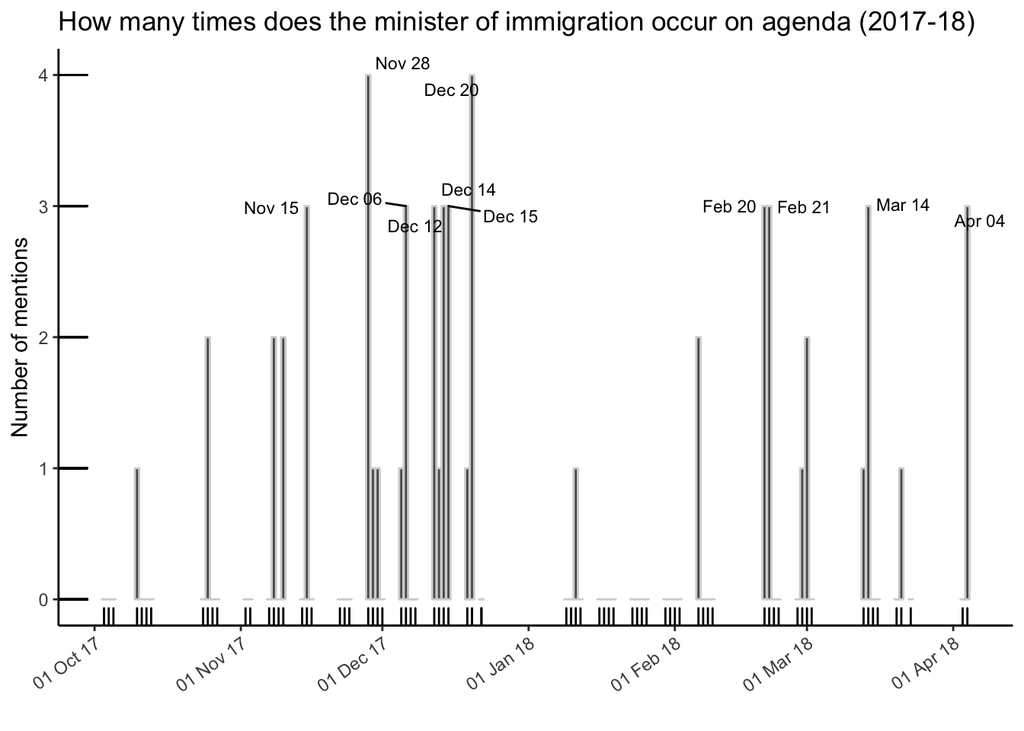

```r
#I import the data
setwd("/Users/thorkilklint/Documents/Berkeley/PS239T_Computational/thorkil-klint-ps239T-final-project/Data")
url_agenda_df_plot<-readRDS("url_agenda_df.Rda")

#I make a label variable with the date of the meeting
url_agenda_df_plot$label<-url_agenda_df_plot$date
url_agenda_df_plot$label[url_agenda_df_plot$mentions<3]<-NA
url_agenda_df_plot$label<-format(url_agenda_df_plot$label, format="%b %d")

#Now I can make a plot of when the Minister of immigration is on the agenda
ggplot(url_agenda_df_plot, aes(x=date, y=mentions, label=label))+
  geom_col(col="gray83")+
  theme_classic()+
  theme(axis.text.x = element_text(angle = 35, hjust = 1))+
  labs(title="How many times does the minister of immigration occur on agenda (2017-18)")+
    ylab("Number of mentions") +
    xlab("")+
    scale_x_date(date_labels = "%d %b %y", date_breaks = "month")+
  geom_text_repel(size = 3)+
  geom_rug()
```

```r
#Export the plot
plot1<-ggplot(url_agenda_df_plot, aes(x=date, y=mentions, label=label))+
  geom_col(col="gray83")+
  theme_classic()+
  theme(axis.text.x = element_text(angle = 35, hjust = 1))+
  labs(title="How many times does the minister of immigration occur on agenda (2017-18)")+
    ylab("Number of mentions") +
    xlab("")+
    scale_x_date(date_labels = "%d %b %y", date_breaks = "month")+
  geom_text_repel(size = 3)+
  geom_rug()

setwd("/Users/thorkilklint/Documents/Berkeley/PS239T_Computational/thorkil-klint-ps239T-final-project/Results")
ggsave(filename="which_sessions_are_relevant.jpg",
       plot=plot1,
       width=18, height=12, units="cm")
#For the presentation
ggplot(url_agenda_df_plot, aes(x=date, y=mentions, label=label))+
  geom_col(col="gray83")+
  theme_classic()+
  theme(axis.text.x = element_text(angle = 35, hjust = 1, size=13),
        axis.text.y = element_text(size=13),
        title=element_text(size=18),
        axis.title.x=element_text(size=13))+
  labs(title="How many times does the Minister of Immigration\noccur on agenda (2017-18)")+
    ylab("Number of mentions") +
    xlab("")+
    scale_x_date(date_labels = "%d %b %y", date_breaks = "month")+
  geom_text_repel(size = 4)+
  geom_rug()
```

[output not shown]

```r
print(url_agenda_df_plot$date[url_agenda_df_plot$mentions>2])
```

```
##  [1] "2017-11-15" "2017-11-28" "2017-12-06" "2017-12-12" "2017-12-14"
##  [6] "2017-12-15" "2017-12-20" "2018-02-20" "2018-02-21" "2018-03-14"
## [11] "2018-04-04"
```